# Financement des entreprises et des particuliers

Lisa Perherin

Septembre 2024

## LE FINANCEMENT DES ENTREPRISES

Le nombre de faillites d’entreprises sur un an (62 893 à fin août) dépasse depuis plusieurs mois la moyenne observée avant la pandémie (59 342 entre 2010 et 2019). Durant la crise sanitaire, ce chiffre avait fortement diminué, passant sous la barre des 30 000, en grande partie grâce aux mesures de soutien mises en place.

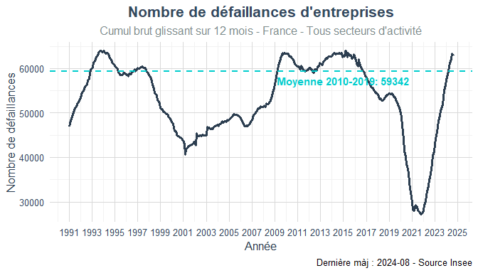

Il est important de souligner le maintien à un niveau élevé des créations d’entreprises ces derniers mois. Entre le 2ᵉ trimestre 2023 et le 2ᵉ trimestre 2024, 1 108 254 entreprises (dont 709 182 micro-entreprises) ont été créées.

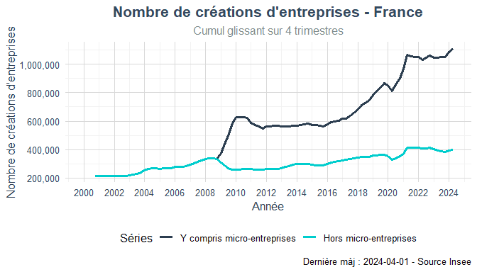

Les entreprises françaises ont constaté une diminution significative de leurs carnets de commandes, en particulier dans les secteurs de l’industrie et du bâtiment, en raison d’un contexte économique mondial difficile.

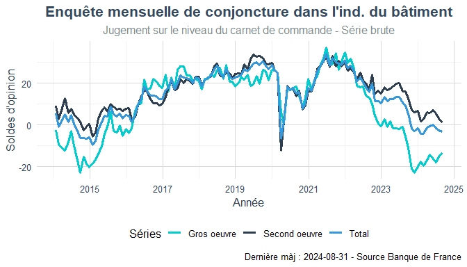

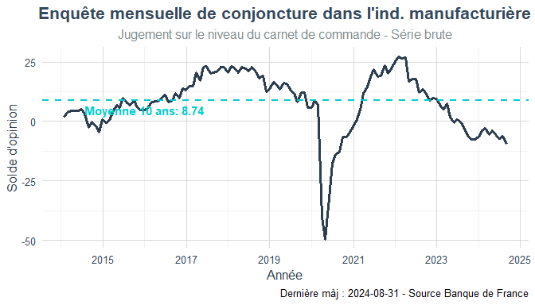

En juillet, l’encours des crédits aux PME a atteint 568 milliards d’euros, représentant près de la moitié des crédits aux entreprises.

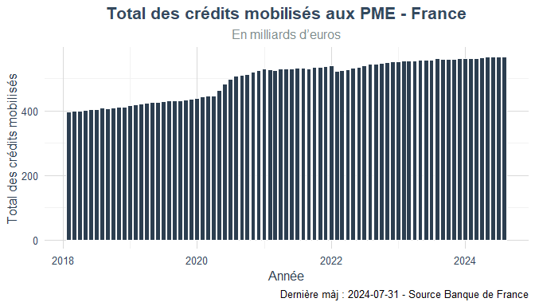

## LE FINANCEMENT DES PARTICULIERS

La production de nouveaux crédits à l’habitat s’établit à 16,44 milliards d’euros en juillet, un niveau supérieur à celui du début de l’année.

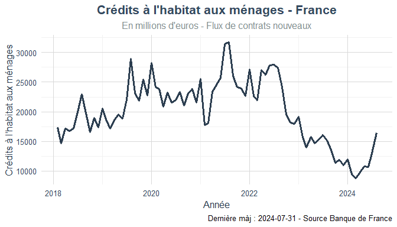

Au total, les crédits aux particuliers en France atteignent 1 525 milliards d’euros à fin juillet 2024, dont 1 284 milliards d’euros de crédits à l’habitat et 210 milliards d’euros de crédits à la consommation.

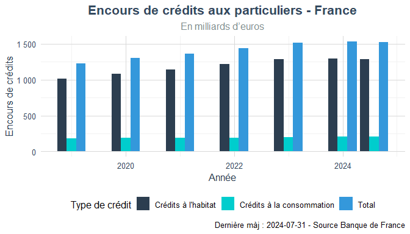

Après deux années de hausses, le taux d’intérêt moyen des nouveaux crédits à l’habitat en France poursuit son repli entamé en février, atteignant 3,41 % en juillet, soit son niveau le plus bas depuis le début de l’année 2024.

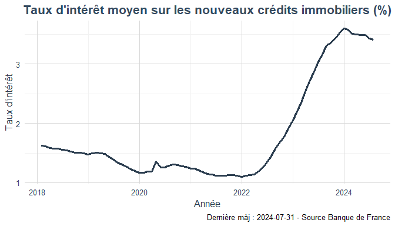